# Ejemplo de reglas de asociación

**En este cuaderno mostraremos un ejemplo sencillo de extracción de reglas de asociación con el conjunto de datos de las cestas de la compra, utilizado en las diapositivas de la asignatura.**

Nos basaremos en las funcionalidades proporcionadas por el paquete [`arules()`](https://cran.r-project.org/web/packages/arules/index.html).

En primer lugar, asignamos una constante para el nombre del fichero:

```r
fichero <- "cesta.csv"
```

# Lectura de datos

Los datos del fichero cesta.csv se presentan en forma de transacciones, como se puede ver:

```r
readLines(fichero) %>% paste0(collapse="\n") %>% cat
```

```
## Transacciones
## pan,leche,pañales
## pan,pañales,cerveza,huevos
## leche,pañales,cerveza,refresco,café
## pan,leche,pañales,cerveza
## pan,refresco,leche,pañales
```

[`arules()`](https://cran.r-project.org/web/packages/arules/index.html) ofrece la función [`read.transactions()`](https://www.rdocumentation.org/packages/arules/versions/1.6-7/topics/read.transactions) para lectura de ficheros con transacciones:

```r
datost <- read.transactions(fichero, sep=",", header = TRUE)
```

Podemos obtener un resumen de las transacciones con `summary()`:

```r
summary(datost)
```

```
## transactions as itemMatrix in sparse format with
##  5 rows (elements/itemsets/transactions) and
##  7 columns (items) and a density of 0.5714286
##
## most frequent items:
##  pañales    leche      pan  cerveza refresco  (Other)
##        5        4        4        3        2        2
##
## element (itemset/transaction) length distribution:
## sizes
## 3 4 5
## 1 3 1
##
##    Min. 1st Qu.  Median    Mean 3rd Qu.    Max.
##       3       4       4       4       4       5
##
## includes extended item information - examples:
##    labels
## 1    café
## 2 cerveza
## 3  huevos
```

Gráficamente, podemos ver los ítems frecuentes de las transacciones:

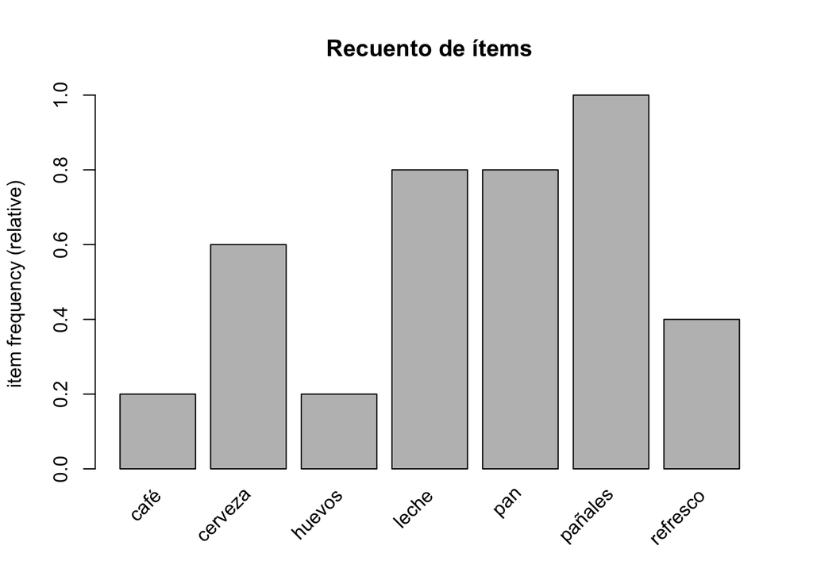

```r
itemFrequencyPlot(datost, type="relative", main="Recuento de ítems")
```

# Listado de transacciones

Para ver y operar con las las transacciones, convertimos `datost` a una lista con [`LIST()`](https://www.rdocumentation.org/packages/arules/versions/1.6-7/topics/LIST):

```r
listat <- LIST(datost)
listat
```

```
## [[1]]
## [1] "leche"   "pan"     "pañales"
##
## [[2]]
## [1] "cerveza" "huevos"  "pan"     "pañales"
##
## [[3]]
## [1] "café"     "cerveza"  "leche"    "pañales"  "refresco"
##
## [[4]]
## [1] "cerveza" "leche"   "pan"     "pañales"
##
## [[5]]
## [1] "leche"    "pan"      "pañales"  "refresco"
```

Si solo queremos trabajar con un subconjunto de transacciones, podemos hacer una sublista:

```r
print("Transacción número 5: ")
```

```
## [1] "Transacción número 5: "
```

```r
listat[[5]]
```

```
## [1] "leche"    "pan"      "pañales"  "refresco"
```

```r
print("Transacciones 1, 3, 5")
```

```
## [1] "Transacciones 1, 3, 5"
```

```r
listat[c(1, 3, 5)]
```

```
## [[1]]
## [1] "leche"   "pan"     "pañales"
##
## [[2]]
## [1] "café"     "cerveza"  "leche"    "pañales"  "refresco"
##
## [[3]]
## [1] "leche"    "pan"      "pañales"  "refresco"
```

Y seleccionar basándonos en criterios más complejos con `which()` y [`grepl()`](https://www.rdocumentation.org/packages/base/versions/3.6.2/topics/grep):

```r
con_pan <- which(grepl("pan", listat))
print("Transacciones que incluyen pan")
```

```
## [1] "Transacciones que incluyen pan"
```

```r
listat[con_pan]
```

```
## [[1]]
## [1] "leche"   "pan"     "pañales"
##
## [[2]]
## [1] "cerveza" "huevos"  "pan"     "pañales"
##
## [[3]]
## [1] "cerveza" "leche"   "pan"     "pañales"
##
## [[4]]
## [1] "leche"    "pan"      "pañales"  "refresco"
```

```r
con_pan_y_leche <- which(grepl("pan", listat) & grepl("leche", listat))
print("Transacciones que incluyen pan y leche")
```

```
## [1] "Transacciones que incluyen pan y leche"
```

```r
listat[con_pan_y_leche]
```

```
## [[1]]
## [1] "leche"   "pan"     "pañales"
##
## [[2]]
## [1] "cerveza" "leche"   "pan"     "pañales"
##
## [[3]]
## [1] "leche"    "pan"      "pañales"  "refresco"
```

# Itemsets frecuentes

Para obtener los itemsets frecuentes, usamos la función [`apriori()`](https://www.rdocumentation.org/packages/arules/versions/1.6-7/topics/apriori) con el `target="frequent itemsets"`:

```r
minSup <- 3/length(listat)

itemsetsFrecuentes <- apriori(datost, parameter = list(support = minSup, target = "frequent itemsets"))
```

```
## Apriori
##
## Parameter specification:
##  confidence minval smax arem  aval originalSupport maxtime support minlen
##          NA    0.1    1 none FALSE            TRUE       5     0.6      1
##  maxlen            target  ext
##      10 frequent itemsets TRUE
##
## Algorithmic control:
##  filter tree heap memopt load sort verbose
##     0.1 TRUE TRUE  FALSE TRUE    2    TRUE
##
## Absolute minimum support count: 3
##
## set item appearances ...[0 item(s)] done [0.00s].
## set transactions ...[7 item(s), 5 transaction(s)] done [0.00s].
## sorting and recoding items ... [4 item(s)] done [0.00s].
## creating transaction tree ... done [0.00s].
## checking subsets of size 1 2 3 done [0.00s].
## sorting transactions ... done [0.00s].
## writing ... [9 set(s)] done [0.00s].
## creating S4 object  ... done [0.00s].
```

```r
inspect(itemsetsFrecuentes)[c(1, 2, 4)]
```

```
##     items               support transIdenticalToItemsets count
## [1] {cerveza}           0.6     0.0                      3
## [2] {pan}               0.8     0.0                      4
## [3] {leche}             0.8     0.0                      4
## [4] {pañales}           1.0     0.0                      5
## [5] {cerveza,pañales}   0.6     0.0                      3
## [6] {leche,pan}         0.6     0.0                      3
## [7] {pan,pañales}       0.8     0.0                      4
## [8] {leche,pañales}     0.8     0.0                      4
## [9] {leche,pan,pañales} 0.6     0.4                      3
```

|  | items | support | count |
| --- | --- | --- | --- |
| [1] | {cerveza} | 0.6 | 3 |
| [2] | {pan} | 0.8 | 4 |
| [3] | {leche} | 0.8 | 4 |
| [4] | {pañales} | 1.0 | 5 |
| [5] | {cerveza,pañales} | 0.6 | 3 |
| [6] | {leche,pan} | 0.6 | 3 |
| [7] | {pan,pañales} | 0.8 | 4 |
| [8] | {leche,pañales} | 0.8 | 4 |
| [9] | {leche,pan,pañales} | 0.6 | 3 |

# Extracción de reglas

## Extracción general

Para obtener las reglas de asociación, lanzamos [`apriori()`](https://www.rdocumentation.org/packages/arules/versions/1.6-7/topics/apriori) cambiando el `target` a `rules`:

```r
minSup  <- 3/length(listat)
minConf <- 0.75

reglas <- apriori(datost,
                  parameter = list(support = minSup,
                                   confidence = minConf,
                                   target = "rules",
                                   minlen = 2,
                                   maxlen = 5))
```

```
## Apriori
##
## Parameter specification:
##  confidence minval smax arem  aval originalSupport maxtime support minlen
##        0.75    0.1    1 none FALSE            TRUE       5     0.6      2
##  maxlen target  ext
##       5  rules TRUE
##
## Algorithmic control:
##  filter tree heap memopt load sort verbose
##     0.1 TRUE TRUE  FALSE TRUE    2    TRUE
##
## Absolute minimum support count: 3
##
## set item appearances ...[0 item(s)] done [0.00s].
## set transactions ...[7 item(s), 5 transaction(s)] done [0.00s].
## sorting and recoding items ... [4 item(s)] done [0.00s].
## creating transaction tree ... done [0.00s].
## checking subsets of size 1 2 3 done [0.00s].
## writing ... [10 rule(s)] done [0.00s].
## creating S4 object  ... done [0.00s].
```

```r
summary(reglas)
```

```
## set of 10 rules
##
## rule length distribution (lhs + rhs):sizes
## 2 3
## 7 3
##
##    Min. 1st Qu.  Median    Mean 3rd Qu.    Max.
##    2.00    2.00    2.00    2.30    2.75    3.00
##
## summary of quality measures:
##     support       confidence      coverage        lift            count
##  Min.   :0.60   Min.   :0.75   Min.   :0.6   Min.   :0.9375   Min.   :3.0
##  1st Qu.:0.60   1st Qu.:0.75   1st Qu.:0.8   1st Qu.:0.9375   1st Qu.:3.0
##  Median :0.60   Median :0.80   Median :0.8   Median :1.0000   Median :3.0
##  Mean   :0.68   Mean   :0.86   Mean   :0.8   Mean   :0.9750   Mean   :3.4
##  3rd Qu.:0.80   3rd Qu.:1.00   3rd Qu.:0.8   3rd Qu.:1.0000   3rd Qu.:4.0
##  Max.   :0.80   Max.   :1.00   Max.   :1.0   Max.   :1.0000   Max.   :4.0
##
## mining info:
##    data ntransactions support confidence
##  datost             5     0.6       0.75
```

# Visualización de reglas

## Formato de tabla

Para mostrar las reglas en forma de tabla usamos `inspect()`:

```r
inspect(reglas)
```

```
##      lhs                rhs       support confidence coverage lift   count
## [1]  {cerveza}       => {pañales} 0.6     1.00       0.6      1.0000 3
## [2]  {pan}           => {leche}   0.6     0.75       0.8      0.9375 3
## [3]  {leche}         => {pan}     0.6     0.75       0.8      0.9375 3
## [4]  {pan}           => {pañales} 0.8     1.00       0.8      1.0000 4
## [5]  {pañales}       => {pan}     0.8     0.80       1.0      1.0000 4
## [6]  {leche}         => {pañales} 0.8     1.00       0.8      1.0000 4
## [7]  {pañales}       => {leche}   0.8     0.80       1.0      1.0000 4
## [8]  {leche,pan}     => {pañales} 0.6     1.00       0.6      1.0000 3
## [9]  {pan,pañales}   => {leche}   0.6     0.75       0.8      0.9375 3
## [10] {leche,pañales} => {pan}     0.6     0.75       0.8      0.9375 3
```

El paquete `dplyr` no se lleva bien con las columnas sin nombre, por lo que lo primero que haremos es renombrar la columna 2 (la implicación):

```r
reglas_df <- inspect(reglas) %>%
  rename("implies" = 2)
```

```
##      lhs                rhs       support confidence coverage lift   count
## [1]  {cerveza}       => {pañales} 0.6     1.00       0.6      1.0000 3
## [2]  {pan}           => {leche}   0.6     0.75       0.8      0.9375 3
## [3]  {leche}         => {pan}     0.6     0.75       0.8      0.9375 3
## [4]  {pan}           => {pañales} 0.8     1.00       0.8      1.0000 4
## [5]  {pañales}       => {pan}     0.8     0.80       1.0      1.0000 4
## [6]  {leche}         => {pañales} 0.8     1.00       0.8      1.0000 4
## [7]  {pañales}       => {leche}   0.8     0.80       1.0      1.0000 4
## [8]  {leche,pan}     => {pañales} 0.6     1.00       0.6      1.0000 3
## [9]  {pan,pañales}   => {leche}   0.6     0.75       0.8      0.9375 3
## [10] {leche,pañales} => {pan}     0.6     0.75       0.8      0.9375 3
```

Ahora ya podemos manipular la tabla con instrucciones `filter()` y búsqueda de texto con `grepl()`:

```r
# reglas con alto soporte
reglas_frecuentes <- reglas_df %>%
  filter(support > 0.6)
reglas_frecuentes
```

|  | lhs | implies | rhs | support | confidence | coverage | lift | count |
| --- | --- | --- | --- | --- | --- | --- | --- | --- |
| [4] | {pan} | => | {pañales} | 0.8 | 1.0 | 0.8 | 1 | 4 |
| [5] | {pañales} | => | {pan} | 0.8 | 0.8 | 1.0 | 1 | 4 |
| [6] | {leche} | => | {pañales} | 0.8 | 1.0 | 0.8 | 1 | 4 |
| [7] | {pañales} | => | {leche} | 0.8 | 0.8 | 1.0 | 1 | 4 |

```r
# reglas con alta confianza
reglas_confianza <- reglas_df %>%
  filter(confidence > 0.8)
reglas_confianza
```

|  | lhs | implies | rhs | support | confidence | coverage | lift | count |
| --- | --- | --- | --- | --- | --- | --- | --- | --- |
| [1] | {cerveza} | => | {pañales} | 0.6 | 1 | 0.6 | 1 | 3 |
| [4] | {pan} | => | {pañales} | 0.8 | 1 | 0.8 | 1 | 4 |
| [6] | {leche} | => | {pañales} | 0.8 | 1 | 0.8 | 1 | 4 |
| [8] | {leche,pan} | => | {pañales} | 0.6 | 1 | 0.6 | 1 | 3 |

```r
# reglas con un item determinado en el consecuente
reglas_pan <- reglas_df %>%
  filter(grepl("pan", rhs))
reglas_pan
```

|  | lhs | implies | rhs | support | confidence | coverage | lift | count |
| --- | --- | --- | --- | --- | --- | --- | --- | --- |
| [3] | {leche} | => | {pan} | 0.6 | 0.75 | 0.8 | 0.9375 | 3 |
| [5] | {pañales} | => | {pan} | 0.8 | 0.80 | 1.0 | 1.0000 | 4 |
| [10] | {leche,pañales} | => | {pan} | 0.6 | 0.75 | 0.8 | 0.9375 | 3 |

```r
# reglas con algún item determinado en el antecedente
reglas_panOleche <- reglas_df %>%
  filter(grepl("pan", lhs) | grepl("leche", lhs))
reglas_panOleche
```

|  | lhs | implies | rhs | support | confidence | coverage | lift | count |
| --- | --- | --- | --- | --- | --- | --- | --- | --- |
| [2] | {pan} | => | {leche} | 0.6 | 0.75 | 0.8 | 0.9375 | 3 |
| [3] | {leche} | => | {pan} | 0.6 | 0.75 | 0.8 | 0.9375 | 3 |
| [4] | {pan} | => | {pañales} | 0.8 | 1.00 | 0.8 | 1.0000 | 4 |
| [6] | {leche} | => | {pañales} | 0.8 | 1.00 | 0.8 | 1.0000 | 4 |
| [8] | {leche,pan} | => | {pañales} | 0.6 | 1.00 | 0.6 | 1.0000 | 3 |
| [9] | {pan,pañales} | => | {leche} | 0.6 | 0.75 | 0.8 | 0.9375 | 3 |
| [10] | {leche,pañales} | => | {pan} | 0.6 | 0.75 | 0.8 | 0.9375 | 3 |

```r
# reglas con un itemset determinado en el antecedente
reglas_panYleche <- reglas_df %>%
  filter(grepl("pan", lhs) & grepl("leche", lhs))
reglas_panYleche
```

|  | lhs | implies | rhs | support | confidence | coverage | lift | count |
| --- | --- | --- | --- | --- | --- | --- | --- | --- |
| [8] | {leche,pan} | => | {pañales} | 0.6 | 1 | 0.6 | 1 | 3 |

También podemos ordenar la tabla de reglas con `arrange()`:

```r
reglas_ordenadas_confianza <- reglas_df %>%
  arrange(desc(confidence))
reglas_ordenadas_confianza
```

|  | lhs | implies | rhs | support | confidence | coverage | lift | count |
| --- | --- | --- | --- | --- | --- | --- | --- | --- |
| [1] | {cerveza} | => | {pañales} | 0.6 | 1.00 | 0.6 | 1.0000 | 3 |
| [4] | {pan} | => | {pañales} | 0.8 | 1.00 | 0.8 | 1.0000 | 4 |
| [6] | {leche} | => | {pañales} | 0.8 | 1.00 | 0.8 | 1.0000 | 4 |
| [8] | {leche,pan} | => | {pañales} | 0.6 | 1.00 | 0.6 | 1.0000 | 3 |
| [5] | {pañales} | => | {pan} | 0.8 | 0.80 | 1.0 | 1.0000 | 4 |
| [7] | {pañales} | => | {leche} | 0.8 | 0.80 | 1.0 | 1.0000 | 4 |
| [2] | {pan} | => | {leche} | 0.6 | 0.75 | 0.8 | 0.9375 | 3 |
| [3] | {leche} | => | {pan} | 0.6 | 0.75 | 0.8 | 0.9375 | 3 |
| [9] | {pan,pañales} | => | {leche} | 0.6 | 0.75 | 0.8 | 0.9375 | 3 |
| [10] | {leche,pañales} | => | {pan} | 0.6 | 0.75 | 0.8 | 0.9375 | 3 |

## Formato visual

El paquete [`arulesViz`](https://cran.r-project.org/web/packages/arulesViz/index.html) incluye varias funcionalidades para la visualización de reglas de asociación.

La más directa es [`plot()`](https://www.rdocumentation.org/packages/arulesViz/versions/1.1-1/topics/plot), que muestra las reglas obtenidas sobre un diagrama de dispersión con x=soporte, y=confianza.

```
## To reduce overplotting, jitter is added! Use jitter = 0 to prevent jitter.
```

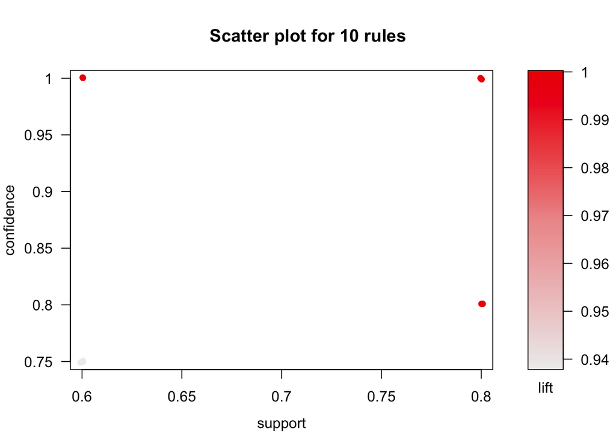

```r
library(arulesViz)   # install.packages("arulesViz")
plot(reglas)
```

[`plot()`](https://www.rdocumentation.org/packages/arulesViz/versions/1.1-1/topics/plot) ofrece varios parámetros para modificar la visualización y el tipo de gráfico generado. Por ejemplo, para formato de coordenadas paralelas:

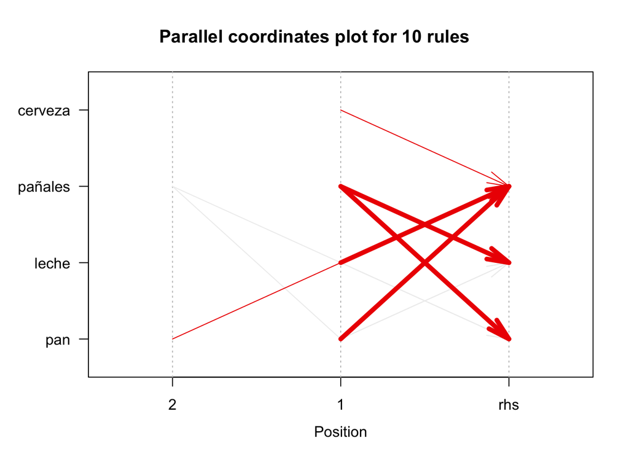

```r
plot(reglas, method="paracoord")    # method="two-key plot"
```

Podemos ver las reglas en formato de grafo. Los nodos del grafo representan reglas (círculos) e ítems (etiquetas de texto); los arcos del grafo representan participación en la regla (antecedente o consecuente, según la dirección del arco).

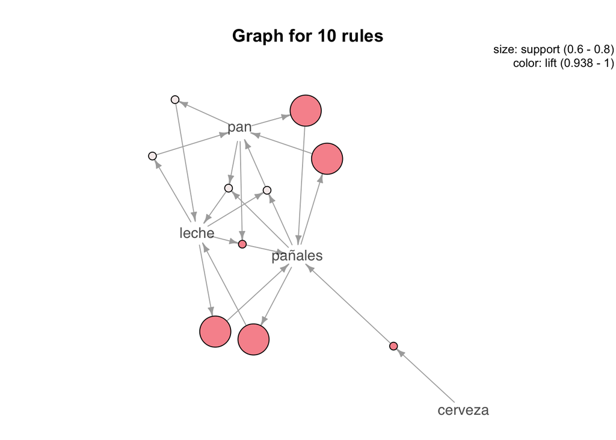

```r
plot(reglas, method="graph")
```

Estos gráficos se pueden hacer interactivos añadiendo el motor HTML para renderizado con `engine = "htmlwidget"`:

```r
plot(reglas, method="graph", engine = "htmlwidget")
```

[interactive chart not shown]

Los grafos de reglas pueden exportarse con [`saveAsGraph()`](https://www.rdocumentation.org/packages/arulesViz/versions/1.4-0/topics/saveAsGraph) a formato *graphml* , que puede ser leído desde [Gephi](https://gephi.org/):

```r
saveAsGraph(reglas, file = "reglas.graphml")
```

# Extensiones del algoritmo de generación

## Extracción centrada en ciertos ítems

Podemos limitar la ejecución del algoritmo para que solo se tengan en cuenta ciertos ítems en el antecedente o el consecuente de las reglas mediante el parámetro `appearance`. En este ejemplo, generamos reglas con leche en el consecuente:

```r
reglas_leche <- apriori(datost,
                        parameter = list(support=0.5, confidence=0.5, minlen=2),
                        appearance = list(default="lhs", rhs="leche"))
```

```
## Apriori
##
## Parameter specification:
##  confidence minval smax arem  aval originalSupport maxtime support minlen
##         0.5    0.1    1 none FALSE            TRUE       5     0.5      2
##  maxlen target  ext
##      10  rules TRUE
##
## Algorithmic control:
##  filter tree heap memopt load sort verbose
##     0.1 TRUE TRUE  FALSE TRUE    2    TRUE
##
## Absolute minimum support count: 2
##
## set item appearances ...[1 item(s)] done [0.00s].
## set transactions ...[7 item(s), 5 transaction(s)] done [0.00s].
## sorting and recoding items ... [4 item(s)] done [0.00s].
## creating transaction tree ... done [0.00s].
## checking subsets of size 1 2 3 done [0.00s].
## writing ... [3 rule(s)] done [0.00s].
## creating S4 object  ... done [0.00s].
```

```r
inspect(reglas_leche)
```

```
##     lhs              rhs     support confidence coverage lift   count
## [1] {pan}         => {leche} 0.6     0.75       0.8      0.9375 3
## [2] {pañales}     => {leche} 0.8     0.80       1.0      1.0000 4
## [3] {pan,pañales} => {leche} 0.6     0.75       0.8      0.9375 3
```

Los resultados son los mismos que si generamos todas las reglas y después filtramos por ítem, aunque el procedimiento es más rápido.

## Eliminado de reglas más amplias que otras

Puede ocurrir que aparezcan reglas que están incluidas dentro de otras reglas. Para identificarlas, usamos la función [`is.subset()`](https://www.rdocumentation.org/packages/arules/versions/1.6-7/topics/is.superset):

```r
is.subset(reglas, reglas)
```

```
## 10 x 10 sparse Matrix of class "ngCMatrix"
```

```
##    [[ suppressing 10 column names '{cerveza,pañales}', '{leche,pan}', '{leche,pan}' ... ]]
```

```
##
## {cerveza,pañales}   | . . . . . . . . .
## {leche,pan}         . | | . . . . | | |
## {leche,pan}         . | | . . . . | | |
## {pan,pañales}       . . . | | . . | | |
## {pan,pañales}       . . . | | . . | | |
## {leche,pañales}     . . . . . | | | | |
## {leche,pañales}     . . . . . | | | | |
## {leche,pan,pañales} . . . . . . . | | |
## {leche,pan,pañales} . . . . . . . | | |
## {leche,pan,pañales} . . . . . . . | | |
```

Si queremos eliminarlas, podemos ver qué reglas tienen un recuento de “inclusión” mayor que 1:

```r
ya_incluidas <- which(colSums(is.subset(reglas, reglas)) > 1)
ya_incluidas
```

```
##         {leche,pan}         {leche,pan}       {pan,pañales}       {pan,pañales}
##                   2                   3                   4                   5
##     {leche,pañales}     {leche,pañales} {leche,pan,pañales} {leche,pan,pañales}
##                   6                   7                   8                   9
## {leche,pan,pañales}
##                  10
```

Y, a continuación, eliminarlas:

```r
reglas_no_incluidas <- reglas[-ya_incluidas]
inspect(reglas_no_incluidas)
```

```
##     lhs          rhs       support confidence coverage lift count
## [1] {cerveza} => {pañales} 0.6     1          0.6      1    3
```